# Модель, описывающая динамику RMR в зависисомтси от хода болезни при заражении птиц разными видами малярии

## Зависимая переменная для модели

Будем рассматривать *log(RMR)*

## Предикторы в модели

В качестве предикторов в модели можно использовать следующие показатели

1. Эксперимент. Дискретный предиктор с тремя уровнями.
2. Текущее значение паразитемии (Parasitemia), оно характеризует инфекцию в момент измерения RMR.
3. Накопленное значение паразитемии (Cum_Parasitemia) хараткеризует “историю” и уровень инфекции. Это, по сути, некоторая оценка численности микрогемипопуляции паразита, побывавшей в организме хозяина на момент измерения RMR.
4. Концентрация итерлейкина в момент измерения RMR (IL) характеризует иммунный ответ в момент измерения RMR.
5. Накопленное значение интерлейкина (Cum_IL) характеризует “историю” и уровень иммунной реакции. То есть это что-то, что говорит о вкладе иммунитета.
6. Масса птицы (Mass) - это “техническая” ковариата.

## Модель для собственно RMR

1. Модель, где рассматривается реакция RMR на “историю” болезни. То есть в качестве предикторов выступают накопленные величины инфекции и иммунитета: Cum_Parasitemia, Cum_IL.
2. Модель, где рассматривется реакция RMR на сотояние в инфекции в данное время. То есть в качестве предикторов выступают величины инфекции и иммунитета непосредственно в день измерения RMR: Parasitemia, IL.
3. Модель, где реакция RMR является функцией и от тех и от других типов величин. То есть в качестве предикторов выступают одновременно Parasitemia, Cum_Parasiemia, IL, Cum_IL.

**Но!**

После ночных размышлений, я понял, что, пожалуй, стоит тогда рассмотреть еще две модели.

4. Модель, где рассматривается “история” болезни с точки зрения инфекции и текущее состояние с точки зрения иммунитета: Cum_Parasitemia, IL
5. Модель, где рассматривается “история” болезни с точки зрения иммунитета и текущее состояние с точки зрения инфекции: Parasitemia, Cum_IL

```r
M1_gam <- gam(log(RMR) ~ s(Cum_Parasitemia, by = Experiment)  + s(Cum_IL, by = Experiment) + Experiment + log(Mass)  + s(Ring, k = 53, bs = "re"),  method = "REML", data = finch_reduced)

M2_gam <- gam(log(RMR) ~ s(Parasitemia, by = Experiment)  + s(IL, by = Experiment) + Experiment + log(Mass)  + s(Ring, k = 53, bs = "re"),  method = "REML", data = finch_reduced)

M3_gam <- gam(log(RMR) ~ s(Cum_Parasitemia, by = Experiment) + s(Parasitemia, by = Experiment) + s(IL, by = Experiment) + s(Cum_IL, by = Experiment) + Experiment + log(Mass)  + s(Ring, k = 53, bs = "re"),  method = "REML", data = finch_reduced)

M4_gam <- gam(log(RMR) ~ s(Cum_Parasitemia, by = Experiment) + s(IL, by = Experiment) + Experiment + log(Mass)  + s(Ring, k = 53, bs = "re"),  method = "REML", data = finch_reduced)


M5_gam <- gam(log(RMR) ~ s(Parasitemia, by = Experiment) +  s(Cum_IL, by = Experiment) + Experiment + log(Mass)  + s(Ring, k = 53, bs = "re"),  method = "REML", data = finch_reduced)
```

```r
AIC(M1_gam, M2_gam, M3_gam, M4_gam, M5_gam)
```

```
##              df       AIC
## M1_gam 48.82506 -390.4828
## M2_gam 45.44017 -364.6554
## M3_gam 64.15590 -377.7846
## M4_gam 48.75572 -386.4784
## M5_gam 54.87226 -385.6617
```

По формальным критериям все равно выигрывает вариант M1_gam. То есть эта модель-кандидат лучше и экономичнее описывает поведение RMR.

**НО!**

Есть нюанс. Я проверил ее на конкурвативность (не знаю как перевести “concurvity”, соизогнутость, что-ли?). Это аналог коллинеарности в случае GAM. Результаты получились не самые приятные. Надо смотреть вторую строку (observed). Если значение теста близко к 1, то есть проблемы. В случае с паразитемией в контроле это нет так страшно, так как там эффекта нет, значение предиктора не варьирует и равно нулю. А вот в остальных смузерах там все не так здорово. Наличие конкурвативности грозит теми же проблемами, что и наличие мультиколлинеарности. В частности, один предиктор маскирует влияние другого предиктора. Возможно, что значимый эффект Cum_IL и незначимый эффект Cum_Parasitemia в случае Exp1 - это проявление именно этой проблемы.

```
##          para s(Cum_Parasitemia):ExperimentCont
## worst       1                      7.164246e+26
## observed    1                      1.000000e+00
## estimate    1                      1.000000e+00
##          s(Cum_Parasitemia):ExperimentExp1 s(Cum_Parasitemia):ExperimentExp2
## worst                            0.9401287                         0.9699506
## observed                         0.8612270                         0.9351994
## estimate                         0.7645699                         0.7894466
##          s(Cum_IL):ExperimentCont s(Cum_IL):ExperimentExp1
## worst                   0.9999496                0.9177309
## observed                0.3019894                0.7681110
## estimate                0.3836565                0.5747886
##          s(Cum_IL):ExperimentExp2  s(Ring)
## worst                   0.9999997 1.000000
## observed                0.8333477 0.370250
## estimate                0.7609540 0.343828
```

Если взять следующую по AIC модель - M4_gam (это, собственно, та самая модель, которая была в отчете malaria_2.html), то проблема немного снижается. Тоже не супер, но критерий конкурвативность заметно снижается.

```
##          para s(Cum_Parasitemia):ExperimentCont
## worst       1                      1.182926e+27
## observed    1                      1.000000e+00
## estimate    1                      1.000000e+00
##          s(Cum_Parasitemia):ExperimentExp1 s(Cum_Parasitemia):ExperimentExp2
## worst                            0.8727011                         0.8281966
## observed                         0.6538449                         0.5261930
## estimate                         0.6014067                         0.7108940
##          s(IL):ExperimentCont s(IL):ExperimentExp1 s(IL):ExperimentExp2
## worst               0.9999983            0.8417505             1.000000
## observed            0.5131374            0.6215541             0.331544
## estimate            0.4777803            0.6733708             0.694540
##            s(Ring)
## worst    1.0000000
## observed 0.4196245
## estimate 0.3797831
```

Для сравнения я привожу обе модели.

## Визуализации модели M1_gam

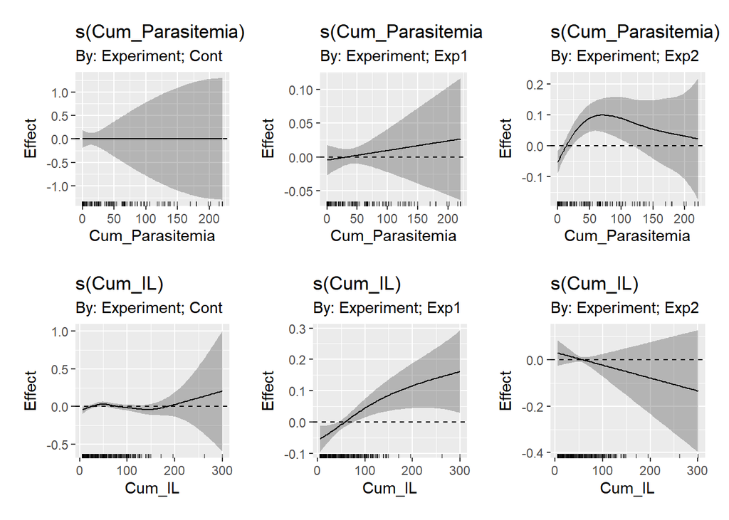

## Визуализации модели M4_gam

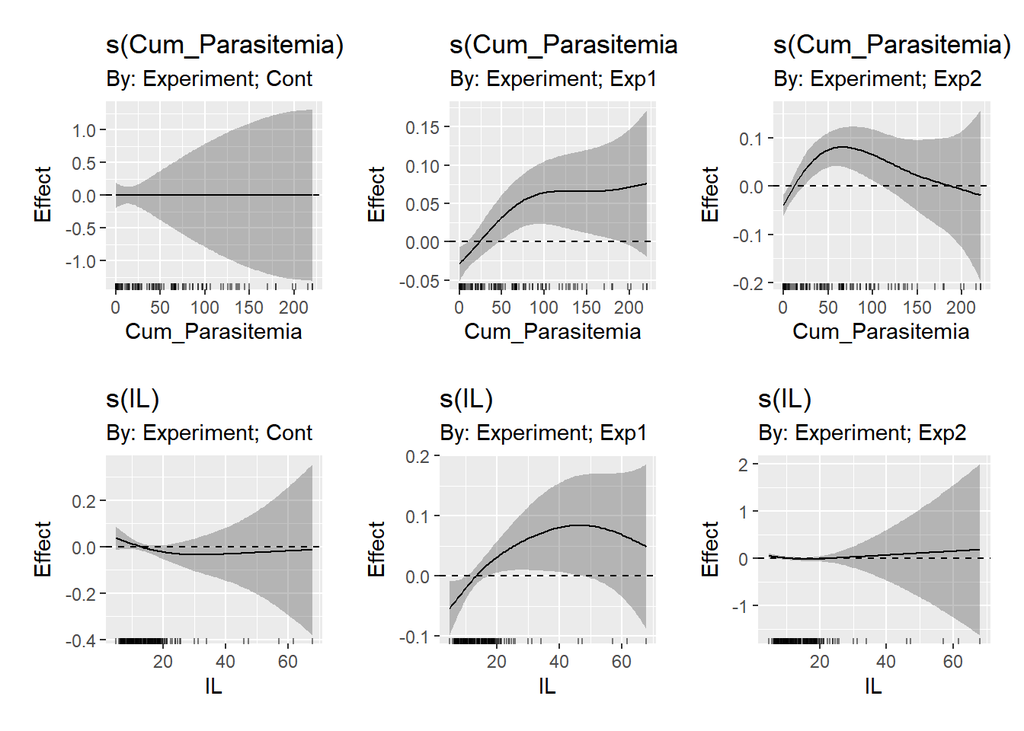

Вот summary от модели M4_gam

```
##
## Family: gaussian
## Link function: identity
##
## Formula:
## log(RMR) ~ s(Cum_Parasitemia, by = Experiment) + s(IL, by = Experiment) +
##     Experiment + log(Mass) + s(Ring, k = 53, bs = "re")
##
## Parametric coefficients:
##                 Estimate Std. Error t value Pr(>|t|)
## (Intercept)     1.798846   0.310752   5.789 3.88e-08 ***
## ExperimentExp1 -0.066025   0.142644  -0.463    0.644
## ExperimentExp2 -0.003485   0.144253  -0.024    0.981
## log(Mass)       0.523368   0.108199   4.837 3.18e-06 ***
## ---
## Signif. codes:  0 '***' 0.001 '**' 0.01 '*' 0.05 '.' 0.1 ' ' 1
##
## Approximate significance of smooth terms:
##                                         edf    Ref.df     F  p-value
## s(Cum_Parasitemia):ExperimentCont 2.925e-16 2.925e-16 0.000 1.000000
## s(Cum_Parasitemia):ExperimentExp1 2.108e+00 2.521e+00 5.494 0.004680 **
## s(Cum_Parasitemia):ExperimentExp2 2.955e+00 3.515e+00 6.454 0.000181 ***
## s(IL):ExperimentCont              1.654e+00 2.003e+00 1.386 0.255029
## s(IL):ExperimentExp1              2.157e+00 2.603e+00 3.311 0.029998 *
## s(IL):ExperimentExp2              1.784e+00 2.174e+00 1.459 0.195496
## s(Ring)                           2.902e+01 5.000e+01 1.664  < 2e-16 ***
## ---
## Signif. codes:  0 '***' 0.001 '**' 0.01 '*' 0.05 '.' 0.1 ' ' 1
##
## Rank: 110/111
## R-sq.(adj) =   0.48   Deviance explained = 59.3%
## -REML = -160.83  Scale est. = 0.0064478  n = 197
```

Видно, что результаты, конечно другие, чем были в Mod1_gam, но по сути они близки. Согласно этой модели, все-таки, на паразита из Exp1 реакция RMR идет и на сигнал от микрогемипопуляции паразитов, и на сигнал от иммунной системы. В случае паразита из Exp2, RMR реагирует только на сигналы от паразита, но не на отклик со стороны иммунной системы. Да и то реакция идет только на первых этапах истории болезни.